# Customer Segmentation and Analysis using K-means Clustering.

-Importing necessary Libraries

```python
import numpy as np # linear algebra
import pandas as pd # data processing, CSV file I/O (e.g. pd.read_csv)
import matplotlib.pyplot as plt
import seaborn as sns
import plotly as py
import plotly.graph_objs as go
from sklearn.cluster import KMeans
import warnings
import os
warnings.filterwarnings("ignore")
py.offline.init_notebook_mode(connected = True)#print(os.listdir("../input"))
```

Data Source: The below data is taken from https://www.kaggle.com/kandij/mall-customers and later I have updated the values according to the requirement.

```python
df = pd.read_csv(r'C:\\Users\\Karan\\Desktop\\kaggle\Updated_Customer_Data.csv')
df.head()
```

|  | CustomerID | Genre | Age | Annual Income (k$) | Spending Score (1-100) |
| --- | --- | --- | --- | --- | --- |
| 0 | 1 | Female | 20 | 25 | 40 |
| 1 | 2 | Male | 19 | 22 | 61 |
| 2 | 3 | Male | 22 | 16 | 15 |
| 3 | 4 | Male | 25 | 34 | 70 |
| 4 | 5 | Female | 40 | 25 | 44 |

The above dataset contains 200 rows and 5 column which are 'CustomerID', 'Gender', 'Age', Annual Income, Spending Score.

```python
df.shape
```

```
(200, 5)
```

The describe function gives a overview of the dataset where we can see that the mean age is 39, Mean Annual income is 61.5 k$ and mean spending score is 50.44

```python
df.describe()
```

|  | CustomerID | Age | Annual Income (k$) | Spending Score (1-100) |
| --- | --- | --- | --- | --- |
| count | 200.000000 | 200.000000 | 200.000000 | 200.000000 |
| mean | 100.500000 | 39.640000 | 61.535000 | 50.445000 |
| std | 57.879185 | 14.398855 | 26.104521 | 25.558426 |
| min | 1.000000 | 18.000000 | 16.000000 | 1.000000 |
| 25% | 50.750000 | 29.000000 | 42.750000 | 34.750000 |
| 50% | 100.500000 | 38.000000 | 62.000000 | 50.000000 |
| 75% | 150.250000 | 49.000000 | 78.000000 | 70.250000 |
| max | 200.000000 | 85.000000 | 145.000000 | 101.000000 |

```python
df.dtypes
```

```
CustomerID                 int64
Genre                     object
Age                        int64
Annual Income (k$)         int64
Spending Score (1-100)     int64
dtype: object
```

The isnull().sum() function will count the missing values in each column

```python
df.isnull().sum()
```

```
CustomerID                0
Genre                     0
Age                       0
Annual Income (k$)        0
Spending Score (1-100)    0
dtype: int64
```

```python
plt.style.use('fivethirtyeight')
```

Histograms

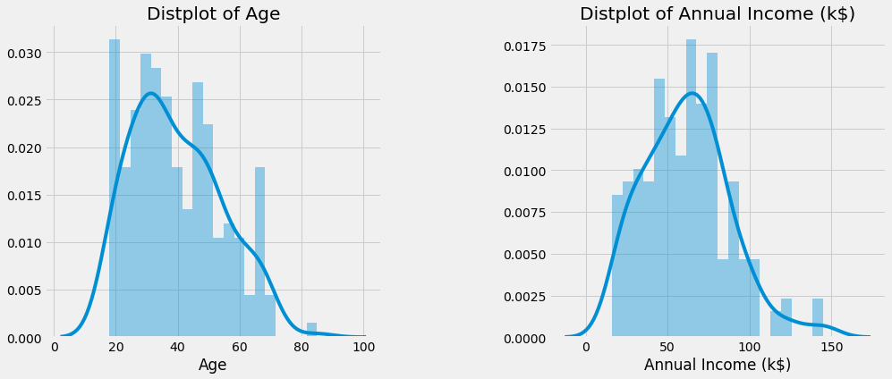

```python
plt.figure(1 , figsize = (15 , 6))
n = 0
for x in ['Age' , 'Annual Income (k$)']:
    n += 1
    plt.subplot(1 , 2 , n)
    plt.subplots_adjust(hspace =0.5 , wspace = 0.5)
    sns.distplot(df[x] , bins = 20)
    plt.title('Distplot of {}'.format(x))
plt.show()
```

We can see the annual income distribution trend and age distribution pattern in the above plots.

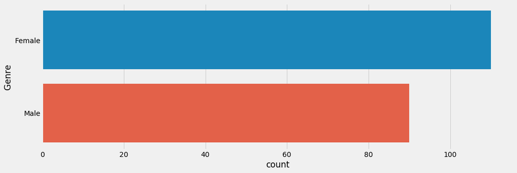

```python
plt.figure(1 , figsize = (15 , 5))
sns.countplot(y = 'Genre' , data = df)
plt.show()
```

By looking at the above chart, you can see how gender is divided in the mall.

Interestingly, Females have more number of count, while Males have less number of count, This is a substantial difference, particularly considering that Males have a higher population than Females.

This clearly states that women are more visiting mall than a average man.

Plotting the relation between Age, Annual Income and Spending Score

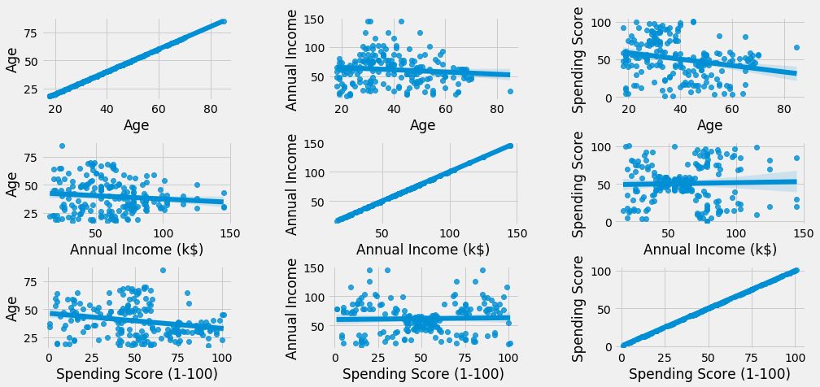

```python
plt.figure(1 , figsize = (15 , 7))
n = 0
for x in ['Age' , 'Annual Income (k$)' , 'Spending Score (1-100)']:
    for y in ['Age' , 'Annual Income (k$)' , 'Spending Score (1-100)']:
        n += 1
        plt.subplot(3 , 3 , n)
        plt.subplots_adjust(hspace = 0.5 , wspace = 0.5)
        sns.regplot(x = x , y = y , data = df)
        plt.ylabel(y.split()[0]+' '+y.split()[1] if len(y.split()) > 1 else y )
plt.show()
```

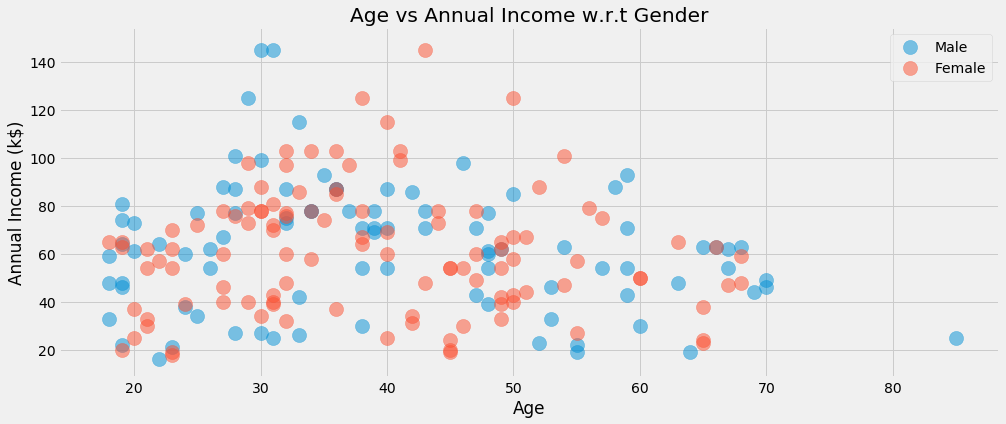

```python
plt.figure(1 , figsize = (15 , 6))
for gender in ['Male' , 'Female']:
    plt.scatter(x = 'Age' , y = 'Annual Income (k$)' , data = df[df['Genre'] == gender] ,
                s = 200 , alpha = 0.5 , label = gender)
plt.xlabel('Age'), plt.ylabel('Annual Income (k$)')
plt.title('Age vs Annual Income w.r.t Gender')
plt.legend()
plt.show()
```

Clustering using K-Means

Segmentation using Age and Spending Score

```python
'''Age and spending Score'''
X1 = df[['Age' , 'Spending Score (1-100)']].iloc[: , :].values
inertia = []
for n in range(1 , 11):
    algorithm = (KMeans(n_clusters = n ,init='k-means++', n_init = 10 ,max_iter=300,
                        tol=0.0001,  random_state= 111  , algorithm='elkan') )
    algorithm.fit(X1)
    inertia.append(algorithm.inertia_)
```

Selecting N Clusters based in inertia(Squared distance between centroids and data points, should be less)

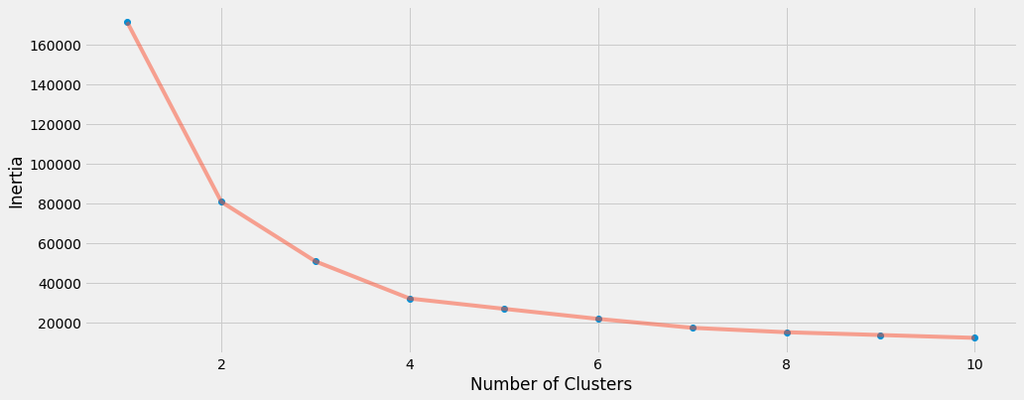

```python
plt.figure(1 , figsize = (15 ,6))
plt.plot(np.arange(1 , 11) , inertia , 'o')
plt.plot(np.arange(1 , 11) , inertia , '-' , alpha = 0.5)
plt.xlabel('Number of Clusters') , plt.ylabel('Inertia')
plt.show()
```

The Optimum Number of cluster is 4, as after 4 we can see a decrease in the curve.

```python
algorithm = (KMeans(n_clusters = 4 ,init='k-means++', n_init = 10 ,max_iter=300,
                        tol=0.0001,  random_state= 111  , algorithm='elkan') )
algorithm.fit(X1)
labels1 = algorithm.labels_
centroids1 = algorithm.cluster_centers_
```

```python
h = 0.02
x_min, x_max = X1[:, 0].min() - 1, X1[:, 0].max() + 1
y_min, y_max = X1[:, 1].min() - 1, X1[:, 1].max() + 1
xx, yy = np.meshgrid(np.arange(x_min, x_max, h), np.arange(y_min, y_max, h))
Z = algorithm.predict(np.c_[xx.ravel(), yy.ravel()])
```

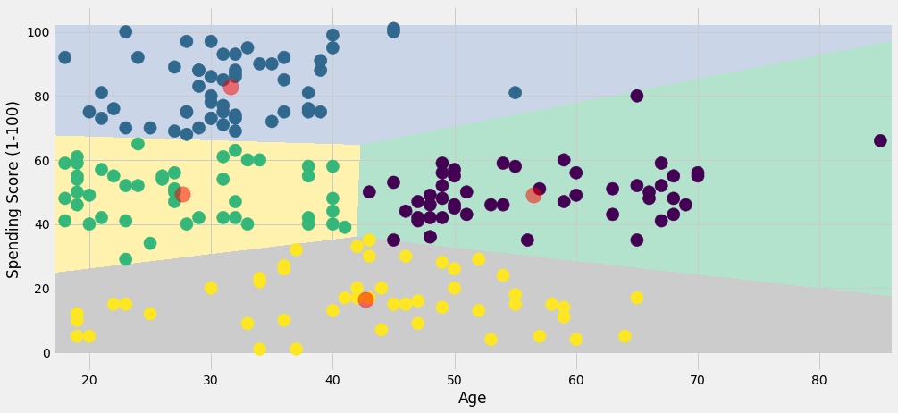

```python
plt.figure(1 , figsize = (15 , 7) )
plt.clf()
Z = Z.reshape(xx.shape)
plt.imshow(Z , interpolation='nearest',
           extent=(xx.min(), xx.max(), yy.min(), yy.max()),
           cmap = plt.cm.Pastel2, aspect = 'auto', origin='lower')

plt.scatter( x = 'Age' ,y = 'Spending Score (1-100)' , data = df , c = labels1 ,
            s = 200 )
plt.scatter(x = centroids1[: , 0] , y =  centroids1[: , 1] , s = 300 , c = 'red' , alpha = 0.5)
plt.ylabel('Spending Score (1-100)') , plt.xlabel('Age')
plt.show()
```

In the above graph, we can see 4 colors or group we can classify it as Group 1 in Blue color - This belongs to people from age 22 - 40 with high spending score above 75. Group 2 in Green color - This belongs to people from age 22 - 40 with medium spending score between 20 - 75. Group 3 in yellow color - This belongs to people from age 20 - 60 with very less spending score less than 25. Group 4 in Purple color - This belongs to people from age 40 - 70 with medium spending score between 20 -75.

Segmentation using Annual Income and spending Score

```python
'''Annual Income and spending Score'''
X2 = df[['Annual Income (k$)' , 'Spending Score (1-100)']].iloc[: , :].values
inertia = []
for n in range(1 , 11):
    algorithm = (KMeans(n_clusters = n ,init='k-means++', n_init = 10 ,max_iter=300,
                        tol=0.0001,  random_state= 111  , algorithm='elkan') )
    algorithm.fit(X2)
    inertia.append(algorithm.inertia_)
```

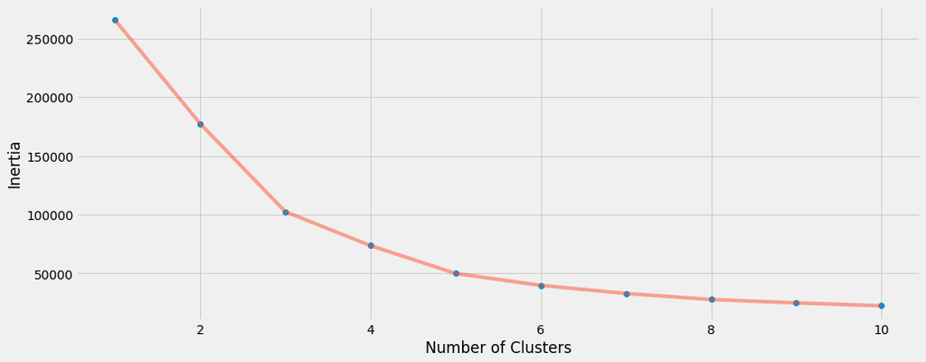

```python
plt.figure(1 , figsize = (15 ,6))
plt.plot(np.arange(1 , 11) , inertia , 'o')
plt.plot(np.arange(1 , 11) , inertia , '-' , alpha = 0.5)
plt.xlabel('Number of Clusters') , plt.ylabel('Inertia')
plt.show()
```

```python
The Optimum Number of cluster is 5, as after 5 we can see a decrease in the curve. so we will form 5 cluster.
```

```python
algorithm = (KMeans(n_clusters = 5 ,init='k-means++', n_init = 10 ,max_iter=300,
                        tol=0.0001,  random_state= 111  , algorithm='elkan') )
algorithm.fit(X2)
labels2 = algorithm.labels_
centroids2 = algorithm.cluster_centers_
```

```python
h = 0.02
x_min, x_max = X2[:, 0].min() - 1, X2[:, 0].max() + 1
y_min, y_max = X2[:, 1].min() - 1, X2[:, 1].max() + 1
xx, yy = np.meshgrid(np.arange(x_min, x_max, h), np.arange(y_min, y_max, h))
Z2 = algorithm.predict(np.c_[xx.ravel(), yy.ravel()])
```

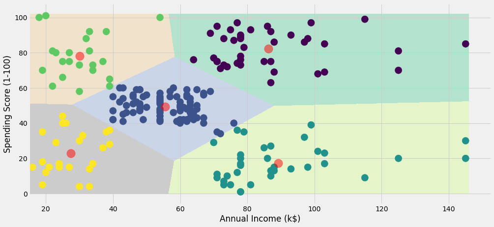

```python
plt.figure(1 , figsize = (15 , 7) )
plt.clf()
Z2 = Z2.reshape(xx.shape)
plt.imshow(Z2 , interpolation='nearest',
           extent=(xx.min(), xx.max(), yy.min(), yy.max()),
           cmap = plt.cm.Pastel2, aspect = 'auto', origin='lower')

plt.scatter( x = 'Annual Income (k$)' ,y = 'Spending Score (1-100)' , data = df , c = labels2 ,
            s = 200 )
plt.scatter(x = centroids2[: , 0] , y =  centroids2[: , 1] , s = 300 , c = 'red' , alpha = 0.5)
plt.ylabel('Spending Score (1-100)') , plt.xlabel('Annual Income (k$)')
plt.show()
```

In the above graph, we can see 5 colors or group we can classify it as Group 1 in light green color, we see people with extremely low annual income between 20 -45 and spending score between 60 - 100 which is extremely high.

Group 2 in yellow color,where we see people with less annual income and spending is also less between 0 - 40 spending score

Group 3 in blue color, they lies exactly in the center of the graph where annual income is between 40-70 and spending score is between 40 - 70.

Group 4 in purple color, which lies in the top right of the graph belongs to people whose annual income is high and spending score is also high.

Group 5 in green color belongs to people who have high annual income with more concentrated between 80 -100 and spending score between 0 - 30.

Segmentation using Age, Annual Income and Spending Score

```python
X3 = df[['Age' , 'Annual Income (k$)' ,'Spending Score (1-100)']].iloc[: , :].values
inertia = []
for n in range(1 , 11):
    algorithm = (KMeans(n_clusters = n ,init='k-means++', n_init = 10 ,max_iter=300,
                        tol=0.0001,  random_state= 111  , algorithm='elkan') )
    algorithm.fit(X3)
    inertia.append(algorithm.inertia_)
```

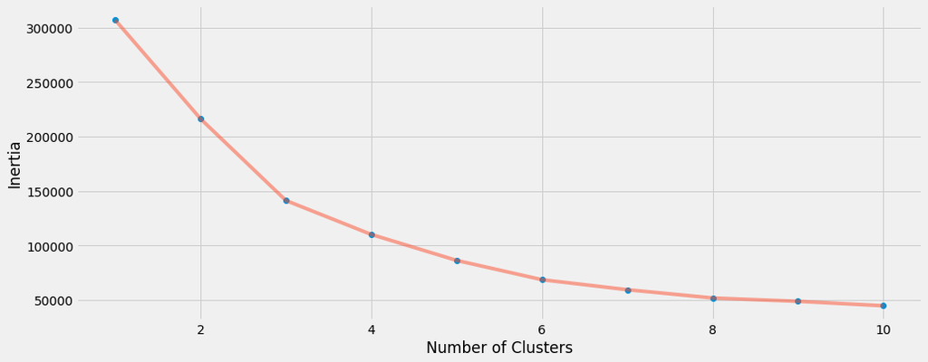

```python
plt.figure(1 , figsize = (15 ,6))
plt.plot(np.arange(1 , 11) , inertia , 'o')
plt.plot(np.arange(1 , 11) , inertia , '-' , alpha = 0.5)
plt.xlabel('Number of Clusters') , plt.ylabel('Inertia')
plt.show()
```

When we Segmentation using Age, Annual Income and Spending Score, The Optimum Number of cluster is6 , as after 6 we can see a decrease in the curve. So, we will form a 3 dimensional graph with age, annual income and spending score and 6 cluster.

```python
algorithm = (KMeans(n_clusters = 6 ,init='k-means++', n_init = 10 ,max_iter=300,
                        tol=0.0001,  random_state= 111  , algorithm='elkan') )
algorithm.fit(X3)
labels3 = algorithm.labels_
centroids3 = algorithm.cluster_centers_
```

```python
df['label3'] =  labels3
trace1 = go.Scatter3d(
    x= df['Age'],
    y= df['Spending Score (1-100)'],
    z= df['Annual Income (k$)'],
    mode='markers',
     marker=dict(
        color = df['label3'],
        size= 20,
        line=dict(
            color= df['label3'],
            width= 12
        ),
        opacity=0.8
     )
)
data = [trace1]
layout = go.Layout(
#     margin=dict(
#         l=0,
#         r=0,
#         b=0,
#         t=0
#     )
    title= 'Clusters',
    scene = dict(
            xaxis = dict(title  = 'Age'),
            yaxis = dict(title  = 'Spending Score'),
            zaxis = dict(title  = 'Annual Income')
        )
)
fig = go.Figure(data=data, layout=layout)
py.offline.iplot(fig)
```

[interactive chart not shown]

Conclusion:

We have converted the unstructured data into meaningful cluster using age, annual income and spending score. This information is very useful and it can generate high profit in business if this data is properly interpreted and promoted to the specific target group.

We can see 6 cluster in the above 3-Dimensional graph which is classified and spread accross the graph taking into consideraton age, annual income and spending score

Group 1 in pink color cluster, This group belong where annual income is between 60-120, age is between 20 - 45 and spending score is between 20-40, Example: In a shopping mall this group can be targetted with latest technology at affordable price as this group belongs to young and middle age people with less spending but a very high annual income.

Group 2 in purple color cluster in the top right side of the graph, his group belong where annual income is between 60-120, age is between 20 - 45 and spending score is between 70-100, Example: In a shopping mall this group can be targetted to sell expensive watches, expensive jewellery, designer clothes as this are people with high annual income with high spending score.

Group 3 in orange color cluster in the bottom right side of the graph, this group belong where annual income is less between 20 - 45 and spending is very high between 80 - 100 and age is between 20 - 40, Example: In a shopping mall this group can be targetted to sell everyday products with new offers and attractiveness, this group have highh spending score but very less annual income, so they can easily buy thinghs which is less expensive and used in everyday life.

Group 4 in maroon color cluster in the bottom left side of the graph, this group belong where annual income is less between 20 - 45, age is less between 20 - 45 and spending score is also very less between 20 - 45. This group is very particular in terms of buying. Example: In a shopping mall this group can be targetted to sell items which are very basic and required in everyday use like in grocery store milk, bread, egg, etc. we can promote some offer like buy 3 carat of egg and you will get bread for 50% of the price.

Group 5 in yellow color cluster in the center, this group contains people with average income and average spending score but they are in the early age between 20 - 40. Example: This people are more into general shopping and they can purchase product with average price and quality

Group 6 in purple color in the center, this group contains people with average income and average spending score but they are in the late age 40 - 80 years. Example: In a shopping mall this group can be targetted to sell items like medicine, health related products, some offers in wheel chair or similar items used during old age.

According to my own intuition by looking at the above graph I gave some example and aggregated them into 6 different categories

Then after getting the results we can accordingly make different marketing strategies and policies to optimize the spending scores of the customer in the Mall.

```python
References:

https://www.kaggle.com/roshansharma/mall-customers-clustering-analysis

https://towardsdatascience.com/machine-learning-algorithms-part-9-k-means-example-in-python-f2ad05ed5203

https://www.analyticsvidhya.com/blog/2019/08/comprehensive-guide-k-means-clustering/
```